# Analysis of Personal Activity

Jiang Bian

September 10, 2017

## Load data from the web

Load the data of the activity monitoring devices from the web (https://d396qusza40orc.cloudfront.net/repdata%2Fdata%2Factivity.zip). This device collects data at 5 minute intervals through out the day. The data consists of two months of data from an anonymous individual collected during the months of October and November, 2012 and include the number of steps taken in 5 minute intervals each day.

```r
df <- read.csv("activity.csv") %>% tbl_df()
summary(df)
```

```
##      steps                date          interval
##  Min.   :  0.00   2012-10-01:  288   Min.   :   0.0
##  1st Qu.:  0.00   2012-10-02:  288   1st Qu.: 588.8
##  Median :  0.00   2012-10-03:  288   Median :1177.5
##  Mean   : 37.38   2012-10-04:  288   Mean   :1177.5
##  3rd Qu.: 12.00   2012-10-05:  288   3rd Qu.:1766.2
##  Max.   :806.00   2012-10-06:  288   Max.   :2355.0
##  NA's   :2304     (Other)   :15840
```

## Basic Analysis

1.Calculate the total number of steps taken per day

```r
r1 <-group_by(df,date) %>% summarise(sum = sum(steps, na.rm = TRUE))
print(data.frame(r1))
```

```
##          date   sum
## 1  2012-10-01     0
## 2  2012-10-02   126
## 3  2012-10-03 11352
## 4  2012-10-04 12116
## 5  2012-10-05 13294
## 6  2012-10-06 15420
## 7  2012-10-07 11015
## 8  2012-10-08     0
## 9  2012-10-09 12811
## 10 2012-10-10  9900
## 11 2012-10-11 10304
## 12 2012-10-12 17382
## 13 2012-10-13 12426
## 14 2012-10-14 15098
```

[output cut: 47 more lines]

2.Make a histogram of the total number of steps taken each day

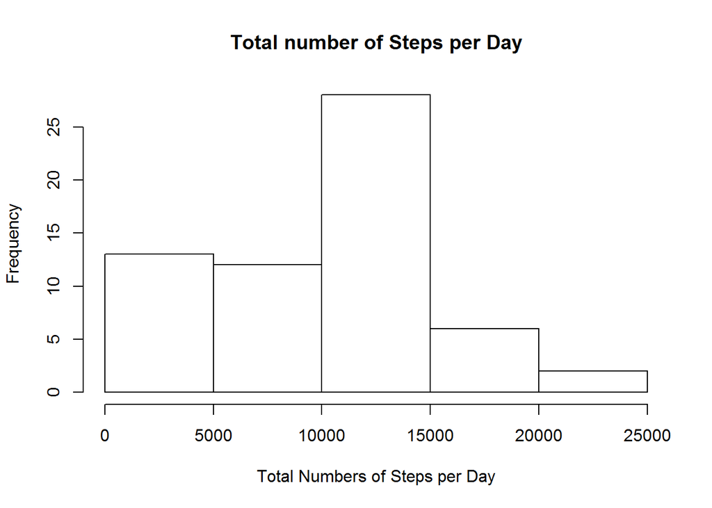

3.Calculate the mean and median of the total number of steps taken per day

```r
r3 <-group_by(df,date) %>% summarise(mean = mean(steps, na.rm = TRUE), median = median(steps, na.rm = TRUE))
print(data.frame(r3))
```

```
##          date       mean median
## 1  2012-10-01        NaN     NA
## 2  2012-10-02  0.4375000      0
## 3  2012-10-03 39.4166667      0
## 4  2012-10-04 42.0694444      0
## 5  2012-10-05 46.1597222      0
## 6  2012-10-06 53.5416667      0
## 7  2012-10-07 38.2465278      0
## 8  2012-10-08        NaN     NA
## 9  2012-10-09 44.4826389      0
## 10 2012-10-10 34.3750000      0
## 11 2012-10-11 35.7777778      0
## 12 2012-10-12 60.3541667      0
## 13 2012-10-13 43.1458333      0
## 14 2012-10-14 52.4236111      0
```

[output cut: 47 more lines]

# Analysis of Daily Activity Pattern

4.Make a time series plot (i.e. type = “l”) of the 5-minute interval (x-axis) and the average number of steps taken, averaged across all days (y-axis)

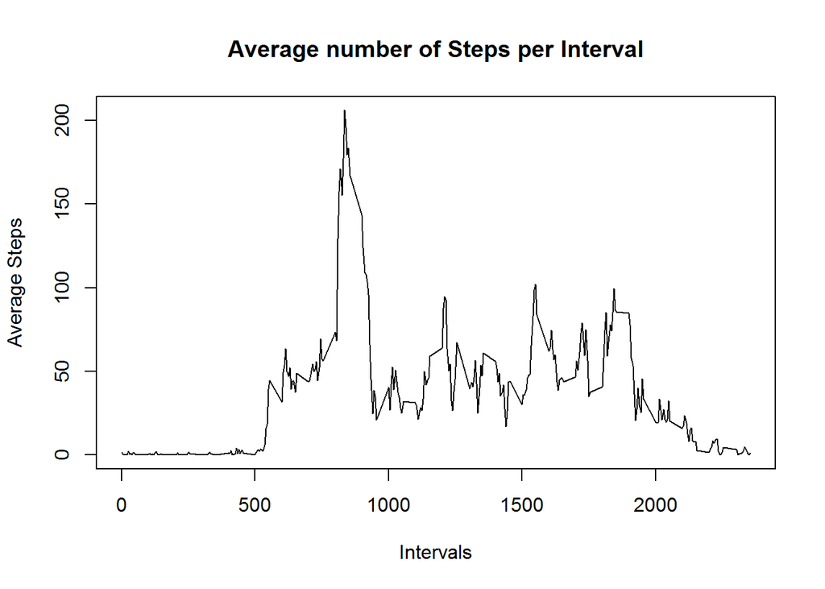

```r
r4 <-group_by(df,interval) %>% summarise(avgsteps = mean(steps, na.rm = TRUE))
plot(r4, type = "l", main ="Average number of Steps per Interval", xlab = "Intervals", ylab = "Average Steps")
```

5.Which 5-minute interval, on average across all the days in the dataset, contains the maximum number of steps?

```r
data.frame(r4[which.max(r4$avgsteps),])
```

```
##   interval avgsteps
## 1      835 206.1698
```

## Imputing missing values

6.Calculate the total number of missing values in the dataset

```r
nrow(r4[is.na(df$steps),])
```

```
## [1] 2304
```

7.Imput missing values in the dataset by using the mean of the corresponding interval

```r
r7 <-group_by(df,interval)
r7 <- merge(r7,r4,all.x = TRUE) %>%
  mutate(avgstepsInt = round(avgsteps,0), steps = ifelse(is.na(steps),avgstepsInt,steps)) %>%
  select(steps,date,interval)
summary(r7)
```

```
##      steps                date          interval
##  Min.   :  0.00   2012-10-01:  288   Min.   :   0.0
##  1st Qu.:  0.00   2012-10-02:  288   1st Qu.: 588.8
##  Median :  0.00   2012-10-03:  288   Median :1177.5
##  Mean   : 37.38   2012-10-04:  288   Mean   :1177.5
##  3rd Qu.: 27.00   2012-10-05:  288   3rd Qu.:1766.2
##  Max.   :806.00   2012-10-06:  288   Max.   :2355.0
##                   (Other)   :15840
```

8.Make a histogram of the total number of steps taken each day.

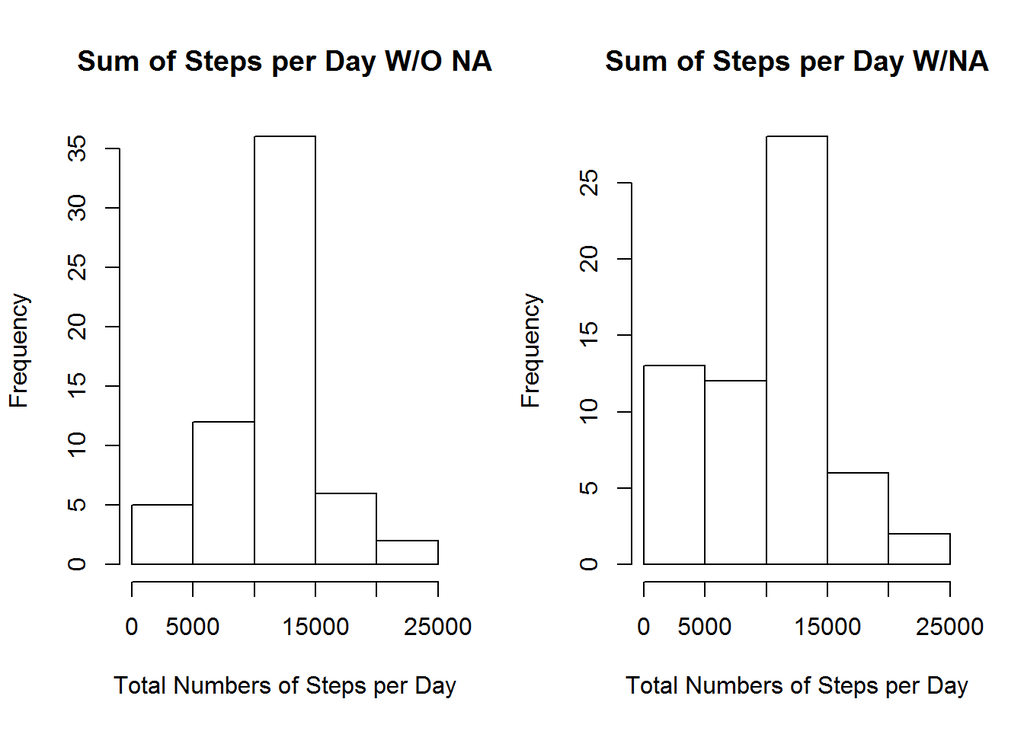

```r
r1 <-group_by(df,date) %>% summarise(sum = sum(steps, na.rm = TRUE))
r8 <-group_by(r7,date) %>% summarise(sum = sum(steps, na.rm = TRUE))
par( mfrow = c( 1, 2))
hist(r8$sum,main ="Sum of Steps per Day W/O NA", xlab = "Total Numbers of Steps per Day", ylab = "Frequency")
hist(r1$sum,main ="Sum of Steps per Day W/NA", xlab = "Total Numbers of Steps per Day", ylab = "Frequency")
```

9.Calculate the mean and median total number of steps taken per day

```r
r91 <-c(mean(r8$sum, na.rm = TRUE),mean(r1$sum,na.rm = TRUE))
r92 <-c(median(r8$sum, na.rm = TRUE),median(r1$sum,na.rm = TRUE))
r9 <- data.frame(rbind(r91,r92))
row.names(r9) <-c("Mean","Median")
colnames(r9)  <-c("Without NA","With NA")
print(r9)
```

```
##        Without NA  With NA
## Mean     10765.64  9354.23
## Median   10762.00 10395.00
```

## Are there differences in activity patterns between weekdays and weekends?

10. Create a new factor variable in the dataset with two levels - “weekday” and “weekend” indicating whether a given date is a weekday or weekend day.Then make a panel plot containing a time series plot (i.e. type = “l”) of the 5-minute interval (x-axis) and the average number of steps taken, averaged across all weekday days or weekend days (y-axis).

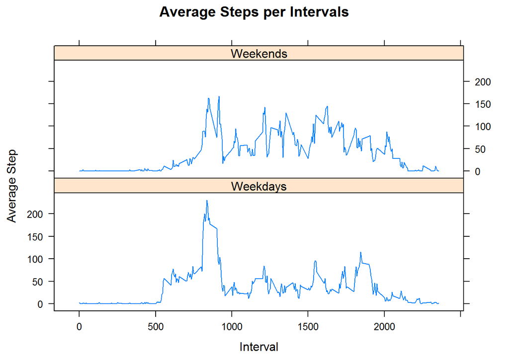

```r
library(lattice)
r10 <- transform(r7, date = as.Date(date)) %>%
  mutate(IsWeekend = as.factor(ifelse(weekdays(date) %in% c("Saturday", "Sunday"),1,0))) %>%
  group_by(IsWeekend,interval) %>% summarise(mean = mean(steps, na.rm=TRUE))

xyplot(mean~interval|IsWeekend,r10,type="l", layout = c(1,2),
      strip = strip.custom(factor.levels=c("Weekdays","Weekends")),
      main="Average Steps per Intervals",
      xlab="Interval",
      ylab="Average Step")
```